# Introduction to `synthesizer`

Mark P.J. van der Loo

Package version 0.6.0. Please use `citation('synthesizer')` to cite the package.

## Introduction

`synthetiser` is an R package for quickly and easily synthesizing data. It also provides a few basic functions based on pMSE to measure some utility of the synthesized data.

The package supports numerical, categorical/ordinal, and mixed data, it synthesizes times series (`ts`) objects and also correctly takes account of missing values and mixed (or zero-inflated) distributions. A `rankcor` parameter lets you gradually shift between realistic data with high utility and less realistic data with decreased correlations between original and syntesized data.

## Installation

The latest CRAN release can be installed as follows.

```
install.packages("synthesizer")
```

Next, the package can be loaded. You can use `packageVersion` (from base R) to check which version you have installed.

```r
> library(synthesizer)
> # check the package version
> packageVersion("synthesizer")
[1] ‘0.6.0’
```

## A first example

We will use the `iris` dataset, that is built into R.

```r
> data(iris)
> head(iris)
  Sepal.Length Sepal.Width Petal.Length Petal.Width Species
1          5.1         3.5          1.4         0.2  setosa
2          4.9         3.0          1.4         0.2  setosa
3          4.7         3.2          1.3         0.2  setosa
4          4.6         3.1          1.5         0.2  setosa
5          5.0         3.6          1.4         0.2  setosa
6          5.4         3.9          1.7         0.4  setosa
```

Creating a synthetic version of this dataset is easy.

```r
> set.seed(1)
> synth_iris <- synthesize(iris)
```

To compare the datasets we can make some side-by-side scatterplots.

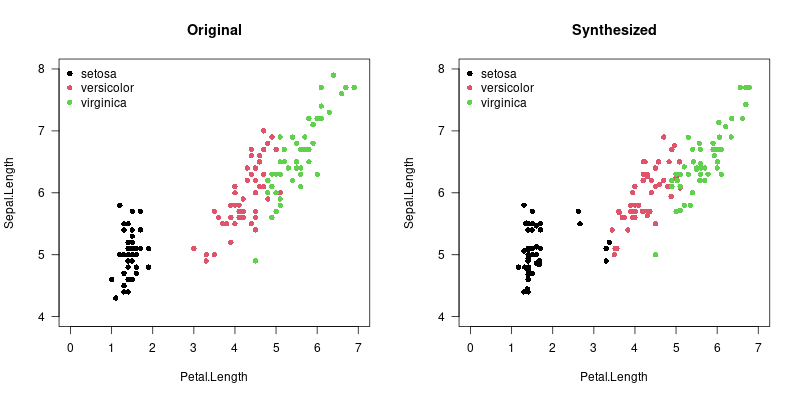

Original and Synthesized Iris

By default `synthesize` will return a dataset of the same size as the input dataset. However, it is possible to ask for any number of records.

```r
> more_synth <- synthesize(iris, n=250)
> dim(more_synth)
[1] 250   5
```

## Controlling the utility-privacy trade-off

Synthetic data can be too realistic, in the sense that it might reveal actual properties of the original entities used to create the synthetic data. One way to mitigate this is to decrease the rank correlation between the original and the synthetic data.

When synthesizing data frames this can be controlled with the `rankcor` parameter. This parameter varies from 0, representing the lowest utility, to 1, the default and maximum utility. The `rankcor` refers to the maximum rank correlation between original and synthesized variables. If `rankcor` is a single (unnamed) value, all synthetic variables are rank-decorrelated from the original data by random permutations until the rank correlation between synthetic and original data drops below the `rankcor` value. It is also possible to lower the utility of a selection of variables. Variables for which `rankcor` is not specified will default to perfect rank correlation (`rankcor=1`).

```r
> # decorrelate rank matching to 0.5
> s1 <- synthesize(iris, rankcor=0.5)
> # decorrelate only Species
> s2 <- synthesize(iris, rankcor=c("Species"=0.5))
```

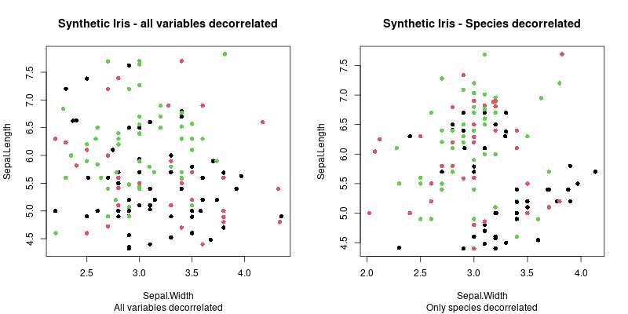

Two versions of syntetic iris

In the left figure, we show the three variables of a synthesized `iris` dataset, where all variables are decorrelated. Both the geometric clustering and the species are now garbled. In the right figure we only decorrelate the Species variable. Here, the spatial clustering is retained while the correlation between color (Species) and location is lost.

## Synthesizing (multivariate) time series

Synthesizing time series is as easy as synthesizing data frames, but there are a few differences.

- Synthesized time series must have the same number of data points as the original data. Forecasts or backcasts from the original data are not possible.
- There is no `rankcor` parameter for time series data.

As a demonstration, we create a synthetic version of the `UKDriverDeaths` dataset that is included with base R.

```r
> data(UKDriverDeaths)
> synth_udd <- synthesize(UKDriverDeaths)
```

Below is a plot of the original and synthetic dataset.

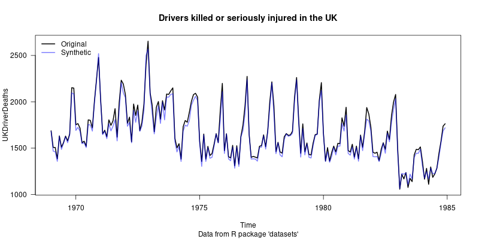

Original and synthetic time series

## How it works

Synthetic data is generated in two steps:

1. For numerical variables, use inverse transform sampling based on a linear interpolation of the emperical quantile function; for all other variable types, sample with replacement. This yields a set of synthetic variables with univariate distributions close to their originals.
2. Reconstruct (linear or nonlinear) correlations by ensuring that the rank order of each synthetic variable matches that of the original data.

These steps ensure a synthetic dataset that closely resembles the original data. The rank order matching ensures a certain resiliance to the influence of outliers. If the `rankcor` argument has a value less than the default 1, a third step is performed:

3. Randomly choose a block of consecutive values in the synthetic data and permute it randomly. Iterate these two steps until the rank correlation between the original and synthetic data drops below the specified `rankcor` value.

Except for the case of time series it is possible to sample datasets that are larger or smaller than their originals. This is done by (if necessary) creating multiple synthetic datasets and sample records uniformly without replacement from the combined dataset.